Coding Essentials for Astronomers

# Astropy: Time, Observation Planning, and FITS Files

## Introduction

In Lecture 13, you learned how to query astronomical databases, work with physical units, transform between coordinate systems, and compute 3D space velocities. You can now find any star in the Gaia catalog and calculate where it is in the Galaxy.

But here's the problem: **knowing where something is doesn't tell you when you can observe it.**

Imagine you're planning to observe a fascinating high-velocity star you found in the Gaia catalog. Is it visible tonight from Columbus? What time does it rise above the horizon? When is it highest in the sky with the least atmospheric distortion? Is the Moon going to wash out your faint target with its bright light? And once you finally get your observation, how do you work with the actual image data that comes from the telescope?

These are practical questions every observational astronomer faces. Professional observatories receive far more proposals than available telescope time, so you need to write proposals showing exactly when your targets are observable and why that time window works. You need to plan efficient observing schedules that maximize science return from precious telescope hours.

This lecture teaches you how astronomical time systems work and why we need several different definitions of "time", how to define your observatory location and transform coordinates to the telescope's natural pointing frame, how to determine when any object is visible and compute its observing quality throughout the night, how to account for Sun and Moon positions in observation planning, and how to read and visualize FITS files from space telescopes like JWST.

By the end, you'll be able to plan complete observing sessions for any target from any location on Earth, create visibility plots showing optimal observing windows, and work with real astronomical images in the FITS format used by every major observatory.

Let's start by understanding why time in astronomy is more complicated than you might think...

As always, we begin by importing the standard scientific Python libraries:

```python
import numpy as np
import pandas as pd
import matplotlib.pyplot as plt

# Set pandas display options for readable output
pd.set_option('display.max_columns', 20)
pd.set_option('display.width', 120)
pd.set_option('display.precision', 3)

# Plotting defaults
plt.rcParams['figure.figsize'] = (12, 8)
plt.rcParams['font.size'] = 12

print("Basic libraries loaded!")
```

```
Basic libraries loaded!
```

## Astronomical Time Systems

### Why Time is Complicated in Astronomy

You might think time is simple - just count seconds from some starting point, right? Unfortunately, things are more subtle than that. Earth's rotation is not constant. It's gradually slowing down due to tidal friction from the Moon at about 2 milliseconds per century. Earthquakes can change the rotation rate by microseconds overnight. Earth wobbles on its axis. Atmospheric and oceanic circulation transfer angular momentum between different parts of the planet.

These variations matter enormously for modern astronomy and technology. GPS satellites must know their position to within meters, which requires nanosecond timing precision. Deep space missions need to account for relativistic time dilation, where clocks actually tick at different rates depending on their gravitational potential and velocity. Astronomical observations must be timed precisely to compare events across different observatories or to study rapid phenomena like pulsars.

Different applications require different time standards. Civil society needs time that stays synchronized with the Sun's position so noon happens when the Sun is roughly highest. Atomic physics laboratories need perfectly uniform time with no variations. Solar system dynamics simulations need time centered on the solar system's center of mass, not Earth.

Rather than try to force one definition of "time" to serve all these purposes, astronomers have developed several coordinated time scales. Astropy provides tools to work with all the major time systems and convert between them seamlessly.

### The Four Major Time Scales

**UTC (Coordinated Universal Time)** is "civil time", the time displayed on your phone and computer. UTC must keep noon synchronized with the Sun's position in the sky - we want noon to happen when the Sun is roughly overhead, not drifting earlier or later over the years. Since Earth's rotation is slowing down due to tidal friction from the Moon, we periodically add leap seconds (roughly every 18 months on average) to prevent noon from drifting away from the Sun's actual position. Without these corrections, over centuries noon would gradually shift to happen at night! Because of these irregular leap second insertions, UTC does not flow uniformly - some "minutes" have 61 seconds.

**TAI (International Atomic Time)** is perfectly uniform atomic clock time that counts pure SI seconds with NO adjustments whatsoever. TAI has no leap seconds - it just ticks forward uniformly forever based on an ensemble of atomic clocks around the world. As of 2025, TAI is now 37 seconds ahead of UTC from all those leap seconds that have been added to UTC since the system began in 1972. Every time we add a leap second to UTC to keep it synchronized with Earth's rotation, TAI pulls further ahead.

**TT (Terrestrial Time)** is the time standard used for computing celestial positions as seen from Earth. The definition is TT = TAI + 32.184 seconds. This 32.184 second offset is purely historical - it ensures continuity with the pre-atomic "Ephemeris Time" standard that was based on Earth's orbital motion around the Sun rather than its rotation. Before atomic clocks, astronomers defined time using Earth's orbit because the orbit is much more stable than Earth's rotation. The offset preserves that connection. So TT is currently 37 + 32.184 = 69.184 seconds ahead of UTC.

**TDB (Barycentric Dynamical Time)** is time at the solar system barycenter - the center of mass of the entire solar system, which is actually slightly outside the Sun's surface due to Jupiter's gravitational influence. TDB is used for planetary dynamics and computing orbits. Due to relativistic effects (both special relativity from Earth's orbital velocity and general relativity from Earth's gravitational potential), clocks on Earth actually tick slightly slower than clocks would at the barycenter. TDB differs from TT by up to ±1.6 milliseconds depending on where Earth is in its orbit around the Sun.

For observation planning, you'll primarily use UTC for your local time zone converted to UTC, and TT for computing where objects appear in the sky. Don't worry if this seems abstract - we'll see concrete examples momentarily.

### Creating and Manipulating Time Objects

Astropy's `Time` class handles all these time scales and their conversions. Let's start with the simplest operation, getting the current time from your computer's system clock:

```python
from astropy.time import Time
import astropy.units as u

# Query system clock for current time
now = Time.now()

print(f"Current time (UTC): {now}")
print(f"ISO 8601 format: {now.iso}")
print(f"Just the date: {now.datetime.date()}")
```

```
Current time (UTC): 2025-11-01 09:11:47.357931
ISO 8601 format: 2025-11-01 09:11:47.358
Just the date: 2025-11-01
```

The `Time.now()` function queries your system clock and creates a `Time` object. The `.iso` attribute formats it as an ISO 8601 string (YYYY-MM-DD HH:MM:SS), which is the international standard for date/time representation. The `.datetime` attribute converts to Python's native datetime object, which can be useful if you need to interact with other Python date/time libraries.

More often, you'll want to specify a particular time for your observation planning. You can create `Time` objects from strings in various formats:

```python
# Tonight at 9 PM Eastern Daylight Time
# Columbus, Ohio is UTC-4 in October (EDT)
# So 9 PM EDT = 1:00 AM UTC the next day
tonight_utc = Time('2025-10-19 01:00:00', scale='utc')

print(f"Tonight at 9 PM EDT: {tonight_utc.iso}")
print(f"Julian Date: {tonight_utc.jd:.2f}")
print(f"Modified Julian Date: {tonight_utc.mjd:.2f}")
```

```
Tonight at 9 PM EDT: 2025-10-19 01:00:00.000
Julian Date: 2460967.54
Modified Julian Date: 60967.04
```

Notice we explicitly specified `scale='utc'` to make it clear this is UTC time. Always be careful about time zones when planning observations - a mistake of several hours can mean missing your observing window entirely!

We also displayed the Julian Date (JD) and Modified Julian Date (MJD). These are continuous day counts used extensively in astronomy because they avoid all the complications of calendar systems like leap years and varying month lengths.

### Julian Dates: A Continuous Time Scale

Julian Date (JD) is simply the number of days, including fractional days, since noon UTC on January 1, 4713 BC. Yes, that's nearly 7000 years ago! This ancient reference point was chosen in 1583 by Joseph Scaliger to predate all historical records. The key advantage is that JD provides a continuous count with no months, no years, no leap days to worry about.

Modified Julian Date (MJD) is defined as MJD = JD - 2400000.5. This makes the numbers smaller (MJD is about 60000 now instead of 2460000) and shifts the start of the day from noon to midnight. MJD zero corresponds to November 17, 1858 at midnight.

Astronomers often use MJD in published papers and observation logs. Let's see how to work with these:

```python
# Access Julian Date and Modified Julian Date attributes
print(f"Current JD: {now.jd:.2f}")
print(f"Current MJD: {now.mjd:.2f}")
```

```
Current JD: 2460980.88
Current MJD: 60980.38
```

### Why Reference Epochs Matter

Before we continue with time scales, we need to understand a critical concept: **reference epochs**. Remember in Lecture 13 when we did spatial cross-matching between catalogs? We were matching stars based on their positions, but there's a subtlety we glossed over: stars aren't fixed in the sky - they move! This motion, called proper motion, means a star's position changes over time. When a catalog like Gaia tells you "this star is at RA=100°, Dec=+30°", it needs to specify *when* that position was valid.

This is where **J2000.0** comes in. It's the standard reference epoch used by all modern star catalogs, defined as January 1, 2000 at noon (12:00 TT). When you look up a star in Gaia, its position is given at J2000.0. To find where the star is *today*, you need to apply the motion of the star to propagate the position forward in time.

Let's see what J2000.0 looks like in Astropy:

```python
# The J2000.0 epoch - standard reference for modern star catalogs
j2000 = Time(2451545.0, format='jd', scale='tt')
print(f"\nJ2000.0 epoch: {j2000.iso}")
print(f"This is the reference epoch for Gaia catalog positions!")
```

```
J2000.0 epoch: 2000-01-01 12:00:00.000
This is the reference epoch for Gaia catalog positions!
```

Notice that J2000.0 is defined in the TT (Terrestrial Time) scale, not UTC. This is the standard reference epoch for modern star catalogs like Gaia, which you worked with in Lecture 13. When Gaia gives you a star's position, it's the position at J2000.0. To find where that star is at any other time, you need to account for proper motion to propagate the position forward (or backward) from this reference epoch.

### Converting Between Time Scales

Now let's see why we have all these different time scales. Astropy makes conversion between them trivial - just access the appropriate attribute:

```python
t = Time('2025-10-18 21:00:00', scale='utc')

# Access different time scales via attributes - Astropy handles conversions automatically
print("Same instant in different time scales:")
print(f"UTC:  {t.utc.iso}")
print(f"TAI:  {t.tai.iso}  (37 seconds ahead)")
print(f"TT:   {t.tt.iso}   (69.184 seconds ahead)")
print(f"TDB:  {t.tdb.iso}  (69.184 + small relativistic correction)")

# Compute actual time differences between scales
print(f"\nTime scale differences:")
print(f"TAI - UTC = {(t.tai - t.utc).to(u.s):.3f}")
print(f"TT - UTC = {(t.tt - t.utc).to(u.s):.3f}")
print(f"TDB - TT = {(t.tdb - t.tt).to(u.millisecond):.3f}")
```

```
Same instant in different time scales:
UTC:  2025-10-18 21:00:00.000
```

```
TAI:  2025-10-18 21:00:37.000  (37 seconds ahead)
TT:   2025-10-18 21:01:09.184   (69.184 seconds ahead)
TDB:  2025-10-18 21:01:09.182  (69.184 + small relativistic correction)

Time scale differences:
TAI - UTC = 0.000 s
TT - UTC = 0.000 s
TDB - TT = 0.000 ms
```

For observation planning, here's the practical workflow: You'll work in UTC when thinking about your local time ("What time should I show up at the telescope?"), but Astropy automatically uses TT when computing celestial positions and coordinate transformations. You rarely need to think about this explicitly - the library handles it for you.

### Time Arrays for Observation Planning

When planning observations, you often need to compute how things change throughout a night. This means creating arrays of times, say every 10 minutes from sunset to sunrise, and evaluating object positions at each moment. Astropy makes this easy with vectorized time arithmetic:

```python
start_time = Time('2025-10-19 01:00:00')  # Midnight EDT = 01:00 UTC

# Create array of minute offsets: 0, 10, 20, ..., 710 minutes
time_offsets = np.arange(0, 12*60, 10) * u.minute

# Vectorized time addition - add all offsets at once
times_array = start_time + time_offsets

print(f"Created an array of {len(times_array)} time points")
print(f"First: {times_array[0].iso}")
print(f"Last:  {times_array[-1].iso}")
print(f"Total span: {(times_array[-1] - times_array[0]).to(u.hour)}")
```

```
Created an array of 72 time points
First: 2025-10-19 01:00:00.000
Last:  2025-10-19 12:50:00.000
Total span: 11.833333333333334 h
```

This created 72 time points (12 hours × 6 points per hour) using `np.arange()` to generate the minute offsets and then adding them all at once to the start time. This vectorized approach is both concise and efficient, much better than writing a loop!

We'll use exactly this kind of time array in the next section to track how celestial objects move across the sky as Earth rotates beneath them. But first, we need to understand the coordinate system that telescopes actually use...

## Observer Location and the Horizon Coordinate System

### Why Location Matters

In Lecture 13, you learned about ICRS coordinates (RA, Dec), essentially celestial longitude and latitude that are fixed with respect to distant quasars. These coordinates are "where something is in the sky" in an absolute sense. But they don't tell you whether you can actually *see* that object from your location!

Consider: A star with Dec = -60° (far southern sky) is never visible from Columbus, Ohio at latitude +40°. It's perpetually below our horizon. Conversely, Polaris at Dec ≈ +90° is visible every clear night from Columbus because it never sets. The same stars are visible or invisible from different locations on Earth.

Moreover, even if an object is theoretically visible from your location, its position in your *local* sky changes constantly as Earth rotates. A star rising in the east at sunset will be high overhead at midnight and setting in the west by dawn. To plan observations, you need to know not just "where is this star in the celestial sphere?" but "where will this star appear in *my* sky at the time I want to observe?"

This is where the **Altitude-Azimuth** (AltAz) coordinate system comes in. It's the natural coordinate system for telescopes and observers.

### Defining Your Observatory Location

Before we can transform celestial coordinates to AltAz, we need to tell Astropy where we're observing from. The `EarthLocation` class specifies a point on Earth's surface using geodetic coordinates (latitude, longitude, elevation):

```python
from astropy.coordinates import EarthLocation

# Define observer location using geodetic coordinates
# Latitude: -90° (South Pole) to +90° (North Pole)
# Longitude: -180° to +180° (positive = East, negative = West)
# Height: elevation above WGS84 reference ellipsoid (mean sea level)
columbus = EarthLocation(lat=39.9612*u.deg,
                         lon=-83.0003*u.deg,
                         height=260*u.m)

print(f"Observatory: Columbus, Ohio")
print(f"Latitude: {columbus.lat}")
print(f"Longitude: {columbus.lon}")
print(f"Elevation: {columbus.height}")
```

```
Observatory: Columbus, Ohio
Latitude: 39.961200000000005 deg
Longitude: -83.00029999999998 deg
Elevation: 259.9999999987812 m
```

Latitude ranges from -90° (South Pole) to +90° (North Pole), with 0° at the equator. Longitude ranges from -180° to +180°, with 0° at Greenwich, UK. Positive is eastward, negative is westward. Elevation is height above the WGS84 reference ellipsoid (essentially mean sea level). It affects atmospheric refraction calculations and the exact definition of your horizon.

For major observatories, Astropy has built-in locations you can access by name:

```python
try:
    keck = EarthLocation.of_site('Keck')
    print(f"Keck Observatory (Mauna Kea, Hawaii):")
    print(f"  {keck.lat:.2f}, {keck.lon:.2f}, elevation {keck.height:.0f}")
except:
    keck = EarthLocation(lat=19.8283*u.deg, lon=-155.4783*u.deg, height=4160*u.m)
    print(f"Keck Observatory: {keck.lat:.2f}, {keck.lon:.2f}, {keck.height:.0f}")

try:
    vlt = EarthLocation.of_site('paranal')
    print(f"\nVLT (Paranal, Chile):")
    print(f"  {vlt.lat:.2f}, {vlt.lon:.2f}, elevation {vlt.height:.0f}")
except:
    vlt = EarthLocation(lat=-24.6275*u.deg, lon=-70.4043*u.deg, height=2635*u.m)
    print(f"\nVLT Paranal: {vlt.lat:.2f}, {vlt.lon:.2f}, {vlt.height:.0f}")
```

```
Keck Observatory (Mauna Kea, Hawaii):
  19.83 deg, -155.48 deg, elevation 4160 m

VLT (Paranal, Chile):
  -24.63 deg, -70.40 deg, elevation 2669 m
```

### Understanding Altitude and Azimuth

Now let's define the AltAz coordinate system itself. Unlike RA/Dec which is fixed to the celestial sphere, AltAz is tied to your local horizon and changes as Earth rotates.

**Altitude** (often abbreviated Alt or El for elevation) is the angle above your horizon, measured in degrees. At 0°, an object is exactly on your horizon. At 45°, the object is halfway between horizon and zenith. At 90°, the object is at zenith, directly overhead. Negative altitudes mean the object is below your horizon and not observable.

**Azimuth** (often abbreviated Az) is the compass direction to the object, measured in degrees clockwise from North. At 0° or 360°, you're looking North. At 90°, you're looking East. At 180°, South. At 270°, West.

Here's why this matters practically: When you point a telescope, you're essentially saying "point altitude X and azimuth Y." Modern alt-azimuth telescope mounts have motors that adjust these two axes. The telescope control system takes your target's RA/Dec, converts it to Alt/Az for your location and current time, and slews the telescope accordingly. As Earth rotates, both altitude and azimuth must be continuously adjusted to track the target.

### Creating an AltAz Frame and Transforming Coordinates

To transform any celestial coordinate to AltAz, we need to specify both the observer's location and the observation time. This is because AltAz coordinates depend on both where you are and when you're observing:

```python
from astropy.coordinates import SkyCoord, AltAz

obs_time = Time('2025-10-19 02:00:00')  # 10 PM EDT = 02:00 UTC
obs_location = columbus

# Create AltAz frame specifying both time and location
# This defines the local horizon coordinate system at this moment
altaz_frame = AltAz(obstime=obs_time, location=obs_location)

print(f"Created AltAz frame for:")
print(f"  Time: {obs_time.iso}")
print(f"  Location: Columbus, Ohio")
```

```
Created AltAz frame for:
  Time: 2025-10-19 02:00:00.000
  Location: Columbus, Ohio
```

This `AltAz` frame is like a photograph of your local sky at this particular moment. Now we can ask: "Where does any celestial object appear in this frame?" Let's try it with Vega, one of the brightest stars in the northern hemisphere sky:

```python
# Define Vega's celestial coordinates using sexagesimal format
vega = SkyCoord(ra='18h36m56s', dec='+38d47m01s')

print(f"Vega's celestial coordinates (ICRS):")
print(f"  RA = {vega.ra}")
print(f"  Dec = {vega.dec}")
```

```
Vega's celestial coordinates (ICRS):
  RA = 279.2333333333333 deg
  Dec = 38.78361111111111 deg
```

Now let's transform Vega's position to our local AltAz frame to see where it actually appears in Columbus's sky:

```python
# Transform celestial coordinates to local horizon coordinates
vega_altaz = vega.transform_to(altaz_frame)

print(f"Vega's position from Columbus at 10 PM EDT:")
print(f"  Altitude: {vega_altaz.alt:.2f}")
print(f"  Azimuth: {vega_altaz.az:.2f}")

if vega_altaz.alt.deg > 0:
    print(f"\n✓ Vega is VISIBLE (above your horizon)")

    # Determine compass direction from azimuth
    az = vega_altaz.az.deg
    if az < 45 or az >= 315:
        direction = "North"
    elif az < 135:
        direction = "East"
    elif az < 225:
        direction = "South"
    else:
        direction = "West"
    print(f"Look {direction}, at {vega_altaz.alt.deg:.0f}° above the horizon")
else:
    print(f"\n✗ Vega is NOT visible (below your horizon)")
```

```
Vega's position from Columbus at 10 PM EDT:
  Altitude: 47.91 deg
  Azimuth: 286.99 deg

✓ Vega is VISIBLE (above your horizon)
Look West, at 48° above the horizon
```

The `.transform_to()` method does all the heavy lifting. It accounts for Earth's rotation, your longitude (which determines what part of the sky is overhead), your latitude (which determines what declinations are visible), and the current sidereal time.

In mid-October from Columbus at 10 PM, Vega should be visible in the northwestern sky, descending toward the horizon as autumn progresses. This makes sense - Vega is a "summer star" that is highest around June-August and gradually becomes more westerly and lower as we move into fall.

### Tracking an Object Through the Night

Since AltAz coordinates change with time (unlike fixed RA/Dec), let's see how Vega moves across the sky as the night progresses. We'll compute its altitude every 30 minutes from 8 PM to 6 AM:

```python
start = Time('2025-10-19 00:00:00')  # 8 PM EDT = 00:00 UTC

# Create array of times every 30 minutes for 10 hours
times = start + np.arange(0, 10*60, 30) * u.minute

# Create AltAz frame array - vectorized for all times at once
altaz_frames = AltAz(obstime=times, location=columbus)

# Transform Vega to all frames at once - much faster than looping
vega_altaz_night = vega.transform_to(altaz_frames)

# Convert time differences to hours for plotting
hours_from_start = (times - start).to(u.hour).value

print(f"Computed Vega's position at {len(times)} times throughout the night")
```

```
Computed Vega's position at 20 times throughout the night
```

Now let's visualize how Vega's altitude changes as Earth rotates:

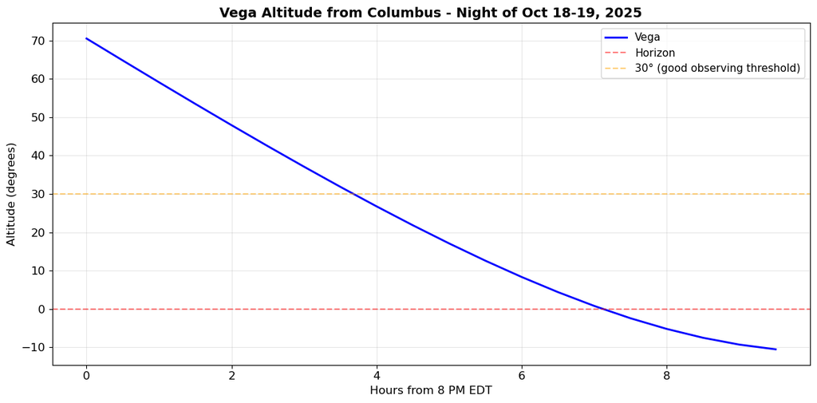

```
Vega sets approximately 7.0 hours after 8 PM
```

```python
plt.figure(figsize=(12, 6))
plt.plot(hours_from_start, vega_altaz_night.alt.deg, 'b-', linewidth=2, label='Vega')
plt.axhline(0, color='r', linestyle='--', alpha=0.5, linewidth=1.5, label='Horizon')
plt.axhline(30, color='orange', linestyle='--', alpha=0.5, linewidth=1.5,
            label='30° (good observing threshold)')
plt.xlabel('Hours from 8 PM EDT', fontsize=12)
plt.ylabel('Altitude (degrees)', fontsize=12)
plt.title('Vega Altitude from Columbus - Night of Oct 18-19, 2025',
          fontsize=14, fontweight='bold')
plt.grid(alpha=0.3)
plt.legend(fontsize=11)
plt.tight_layout()
plt.show()

visible = vega_altaz_night.alt.deg > 0
if visible.any():
    last_visible = np.where(visible)[0][-1]
    setting_time = hours_from_start[last_visible]
    print(f"Vega sets approximately {setting_time:.1f} hours after 8 PM")
```

### Airmass: Quantifying Atmospheric Effects

Altitude tells you *where* an object is in the sky, but how do we quantify observing *quality*? The answer is **airmass**, a measure of how much atmosphere light must traverse to reach your telescope.

When you observe an object at zenith (directly overhead, altitude = 90°), light comes straight down through the minimum atmospheric thickness. We define this as **airmass = 1.0**. At lower altitudes, light enters Earth's atmosphere at an angle and travels through more air before reaching your telescope. For altitudes above about 20°, a good approximation is airmass ≈ sec(zenith_angle) = 1 / cos(zenith_angle), where zenith_angle = 90° - altitude.

Why does airmass matter so much? More atmosphere means more absorption, so objects appear dimmer. More atmosphere means more scattering, reducing contrast. Atmospheric turbulence blurs images more when looking through thick atmosphere. Different wavelengths bend by different amounts, causing color-dependent position shifts called differential refraction.

Professional astronomers use these general guidelines: Airmass < 1.5 (altitude > 42°) is excellent conditions. Airmass < 2.0 (altitude > 30°) is good conditions, acceptable for most science. Airmass > 2.0 (altitude < 30°) is poor conditions, avoid if possible. Airmass > 3.0 (altitude < 19°) is very poor, with data likely unusable. Many observatories set airmass < 2.0 as a hard constraint for proposals. Let's see what this means quantitatively:

```python
example_altitudes = [90, 60, 45, 30, 20, 10] * u.deg

print("Altitude → Airmass → Quality Assessment")
print("=" * 50)

for alt in example_altitudes:
    zenith_angle = 90*u.deg - alt
    airmass = 1.0 / np.cos(zenith_angle)
    if airmass < 1.5:
        quality = "Excellent"
    elif airmass < 2.0:
        quality = "Good"
    elif airmass < 3.0:
        quality = "Poor"
    else:
        quality = "Very Poor"
    print(f"{alt:5.0f}  →  {airmass:4.2f}  →  {quality}")
```

```
Altitude → Airmass → Quality Assessment
==================================================
   90 deg  →  1.00  →  Excellent
   60 deg  →  1.15  →  Excellent
   45 deg  →  1.41  →  Excellent
   30 deg  →  2.00  →  Good
   20 deg  →  2.92  →  Poor
   10 deg  →  5.76  →  Very Poor
```

Notice how quickly airmass grows at low altitudes! At 30°, you're looking through twice as much atmosphere as at zenith. At 10°, it's nearly six times as much. This is why the "30° rule" is so important - below this, observing quality deteriorates rapidly.

Now let's compute and plot airmass for Vega throughout the night:

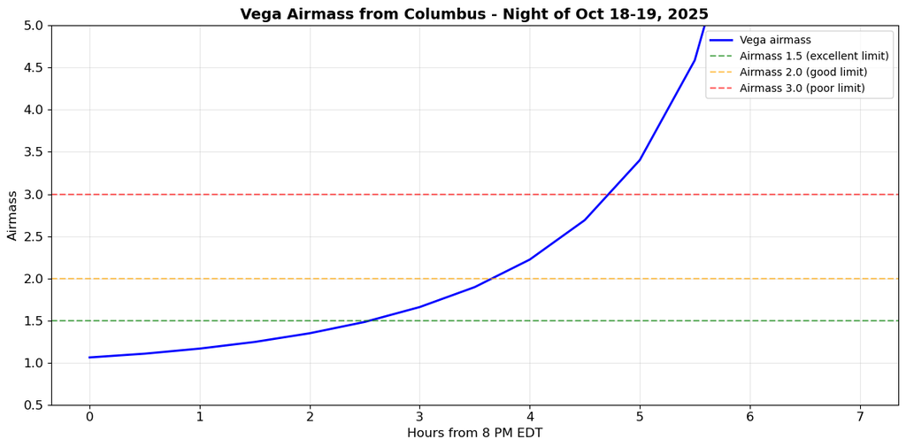

```python
# Calculate airmass using sec(zenith_angle) approximation
zenith_angles = 90*u.deg - vega_altaz_night.alt
airmass_values = 1.0 / np.cos(zenith_angles)

# Create boolean mask for when Vega is visible
visible = vega_altaz_night.alt.deg > 0

plt.figure(figsize=(12, 6))

# Plot only visible portions
plt.plot(hours_from_start[visible], airmass_values[visible],
         'b-', linewidth=2, label='Vega airmass')

# Add reference lines for observing quality thresholds
plt.axhline(1.5, color='green', linestyle='--', alpha=0.6, linewidth=1.5,
            label='Airmass 1.5 (excellent limit)')
plt.axhline(2.0, color='orange', linestyle='--', alpha=0.6, linewidth=1.5,
            label='Airmass 2.0 (good limit)')
plt.axhline(3.0, color='red', linestyle='--', alpha=0.6, linewidth=1.5,
            label='Airmass 3.0 (poor limit)')
plt.xlabel('Hours from 8 PM EDT', fontsize=12)
plt.ylabel('Airmass', fontsize=12)
plt.title('Vega Airmass from Columbus - Night of Oct 18-19, 2025',
          fontsize=14, fontweight='bold')
plt.ylim(0.5, 5)
plt.grid(alpha=0.3)
plt.legend(fontsize=10)
plt.tight_layout()
plt.show()
```

The airmass curve shows observing quality degrading as Vega sinks toward the western horizon. Early in the night (first 2-3 hours), Vega is at acceptable airmass < 2.0. Later, it crosses into poor observing territory. This is why observation scheduling matters - you want to observe targets when they're high in the sky (at transit), not when they're rising or setting!

Now that we understand how to transform coordinates and assess observing quality, let's move on to the most practical question: **when is astronomical night?**

## Observation Planning: Sun, Moon, and Optimal Windows

### The Sun: Defining Night vs. Twilight

You can compute altitude and airmass for any celestial object, but there's one huge constraint we haven't addressed yet: **you can't observe stars when the Sun is up!**

This seems obvious, but it's more subtle than just "Sun above horizon = bad, Sun below horizon = good." Even after the Sun sets, its light continues to scatter in Earth's atmosphere, keeping the sky bright. Conversely, before the Sun rises, the sky begins brightening well before sunrise. These twilight periods limit when you can observe.

Astronomers define three twilight phases based on the Sun's altitude below the horizon. **Civil twilight** occurs when the Sun is between 0° and -6°. This is the brightest twilight. The sky is still quite luminous - you can read a newspaper outside without artificial light. Only the brightest planets and stars are visible. **Nautical twilight** occurs when the Sun is between -6° and -12°. It's darker, but still not truly night. The horizon is visible at sea (hence "nautical"). Bright stars are visible, but the sky background is still too bright for faint object observations. **Astronomical twilight** occurs when the Sun is between -12° and -18°. The sky appears dark to the eye, but scattered sunlight still affects the most sensitive observations. Professional astronomers usually require darker skies for faint objects. **Astronomical night** occurs when the Sun is below -18°. The sky is truly dark. This is when you can observe the faintest objects - distant galaxies, faint nebulae, etc. For bright objects (planets, bright stars), you might tolerate nautical or even civil twilight, but for faint science targets, you need true night.

Let's see how to compute when these conditions occur:

### Computing Sun and Moon Positions

Astropy provides convenient functions to get solar system body positions. Let's start by finding where the Sun is at our observation time:

```python
from astropy.coordinates import get_sun, get_body

obs_time = Time('2025-10-19 02:00:00')  # 10 PM EDT

# Get Sun's position - computed from solar system ephemeris
sun = get_sun(obs_time)

print(f"Sun's celestial position at {obs_time.iso}:")
print(f"  RA: {sun.ra}")
print(f"  Dec: {sun.dec}")
```

```
Sun's celestial position at 2025-10-19 02:00:00.000:
  RA: 203.71458863624974 deg
  Dec: -9.889191327789822 deg
```

But what we really want to know is: **Is the Sun above or below our horizon?** To answer this, we transform the Sun's position to AltAz coordinates for Columbus:

```python
# Transform to local AltAz coordinates
sun_altaz = sun.transform_to(AltAz(obstime=obs_time, location=columbus))

print(f"Sun's position from Columbus at 10 PM EDT:")
print(f"  Altitude: {sun_altaz.alt:.2f}")

# Classify observing conditions based on Sun altitude
sun_alt = sun_altaz.alt.deg
if sun_alt > 0:
    print(f"\n✗ Daytime - Sun is above the horizon")
elif sun_alt > -6:
    print(f"\n⚠ Civil twilight - Too bright for most astronomy")
elif sun_alt > -12:
    print(f"\n⚠ Nautical twilight - OK for bright objects only")
elif sun_alt > -18:
    print(f"\n⚠ Astronomical twilight - Nearly dark, but scattered sunlight present")
else:
    print(f"\n✓ Astronomical night - Truly dark sky!")
```

```
Sun's position from Columbus at 10 PM EDT:
  Altitude: -37.19 deg

✓ Astronomical night - Truly dark sky!
```

At 10 PM in October from Columbus, the Sun should be well below -18°, giving us true astronomical night. Good news for observers!

Now let's check the Moon, which can also interfere with observations (especially when full):

```python
# Get Moon position and transform to local coordinates
moon = get_body('moon', obs_time, columbus)
moon_altaz = moon.transform_to(AltAz(obstime=obs_time, location=columbus))

print(f"Moon's position from Columbus at 10 PM EDT:")
print(f"  Altitude: {moon_altaz.alt:.2f}")
print(f"  Azimuth: {moon_altaz.az:.2f}")

# Estimate lunar phase from Sun-Moon angular separation
# Get both Sun and Moon in GCRS frame at the same location to avoid frame mismatch
sun_gcrs = get_sun(obs_time)
moon_gcrs = get_body('moon', obs_time)  # Without location, returns GCRS at geocenter
sun_moon_separation = sun_gcrs.separation(moon_gcrs)
phase = sun_moon_separation.deg / 180.0 * 100

print(f"\nSun-Moon separation: {sun_moon_separation:.1f}")
print(f"Approximate illumination: {phase:.0f}%")

# Assess lunar interference for observations
if moon_altaz.alt.deg > 0:
    print(f"\n⚠ Moon is UP")
    if phase > 80:
        print(f"   Nearly full - will severely interfere with faint object observations")
    elif phase > 50:
        print(f"   More than half illuminated - moderate interference")
    else:
        print(f"   Crescent phase - minimal interference")
else:
    print(f"\n✓ Moon is DOWN - ideal for observing faint objects!")
```

```
Moon's position from Columbus at 10 PM EDT:
  Altitude: -45.59 deg
  Azimuth: 325.15 deg

Sun-Moon separation: 27.0 deg
Approximate illumination: 15%

✓ Moon is DOWN - ideal for observing faint objects!
```

The Moon's phase matters enormously. A full Moon at magnitude -12.6 is bright enough to cast shadows and significantly brightens the entire sky. Professional observatories classify nights as dark time (new moon or moon down), grey time (quarter moon), or bright time (full moon or nearly full). Faint object proposals typically request dark time, while bright star or planet observations can tolerate bright time.

### Creating a Professional Visibility Plot

Now let's combine everything - target altitude, Sun altitude, Moon altitude, and twilight zones - into a single comprehensive visibility plot. This is the kind of plot you'd include in a telescope proposal to demonstrate your target is observable.

First, let's compute all the positions we need throughout the night:

```python
night_start = Time('2025-10-18 22:00:00')

# Create 100 evenly-spaced times covering 14 hours
hours = np.linspace(0, 14, 100)
night_times = night_start + hours * u.hour

# Create AltAz frames for all times
altaz_frames = AltAz(obstime=night_times, location=columbus)

# Compute positions for Vega, Sun, and Moon - all vectorized
vega_altaz = vega.transform_to(altaz_frames)
sun_coords = get_sun(night_times)
sun_altaz = sun_coords.transform_to(altaz_frames)
moon_coords = get_body('moon', night_times, columbus)
moon_altaz = moon_coords.transform_to(altaz_frames)

print(f"Computed positions for {len(hours)} times throughout the night")
```

```
Computed positions for 100 times throughout the night
```

Now create the visibility plot with continuous twilight shading that darkens from daytime to astronomical night:

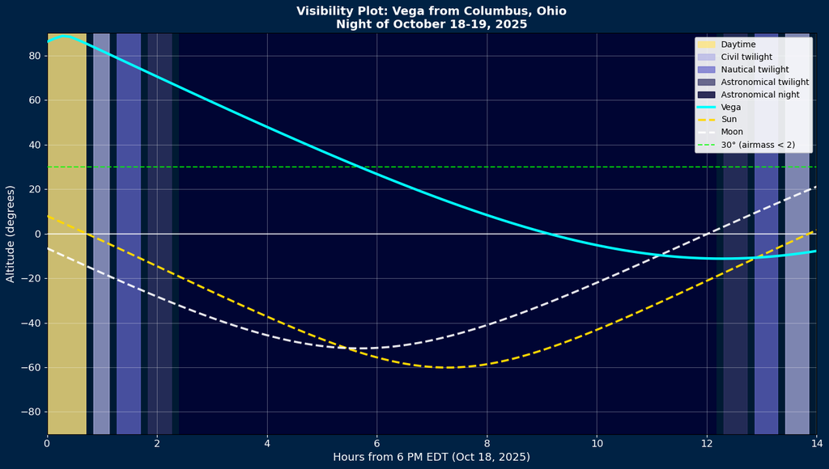

```python
plt.figure(figsize=(14, 8))

# Create twilight zones using fill_between with boolean masks
# Daytime: Sun above horizon
plt.fill_between(hours, -90, 90, sun_altaz.alt.deg > 0,
                 color='#FFE680', alpha=0.8, label='Daytime', zorder=1)

# Civil twilight: Sun 0° to -6°
plt.fill_between(hours, -90, 90, (sun_altaz.alt.deg <= 0) & (sun_altaz.alt.deg > -6),
                 color='#B3B3E6', alpha=0.7, label='Civil twilight', zorder=1)

# Nautical twilight: Sun -6° to -12°
plt.fill_between(hours, -90, 90, (sun_altaz.alt.deg <= -6) & (sun_altaz.alt.deg > -12),
                 color='#6666CC', alpha=0.7, label='Nautical twilight', zorder=1)

# Astronomical twilight: Sun -12° to -18°
plt.fill_between(hours, -90, 90, (sun_altaz.alt.deg <= -12) & (sun_altaz.alt.deg > -18),
                 color='#333366', alpha=0.7, label='Astronomical twilight', zorder=1)

# True astronomical night: Sun below -18°
plt.fill_between(hours, -90, 90, sun_altaz.alt.deg <= -18,
                 color='#000033', alpha=0.8, label='Astronomical night', zorder=1)

# Plot object tracks
plt.plot(hours, vega_altaz.alt.deg, color='#00FFFF', linewidth=3,
         label='Vega', zorder=10)
plt.plot(hours, sun_altaz.alt.deg, color='#FFD700', linewidth=2.5,
         linestyle='--', label='Sun', zorder=5)
plt.plot(hours, moon_altaz.alt.deg, color='#FFFFFF', linewidth=2.5,
         linestyle='--', label='Moon', zorder=5, alpha=0.9)

# Add reference lines
plt.axhline(0, color='white', linestyle='-', alpha=0.7, linewidth=1.5, zorder=3)
plt.axhline(30, color='#00FF00', linestyle='--', alpha=0.8, linewidth=1.5,
            label='30° (airmass < 2)', zorder=3)

plt.xlabel('Hours from 6 PM EDT (Oct 18, 2025)', fontsize=13, color='white')
plt.ylabel('Altitude (degrees)', fontsize=13, color='white')
plt.title('Visibility Plot: Vega from Columbus, Ohio\nNight of October 18-19, 2025',
          fontsize=14, fontweight='bold', color='white')
plt.xlim(0, 14)
plt.ylim(-90, 90)
plt.legend(loc='upper right', fontsize=10, fancybox=True, framealpha=0.9)
plt.grid(alpha=0.3, color='white')

ax = plt.gca()
ax.set_facecolor('#001a33')
plt.gcf().patch.set_facecolor('#002244')
ax.tick_params(colors='white', which='both')

plt.tight_layout()
plt.show()
```

This professional visibility plot immediately shows color-coded twilight zones showing progression from day to night, the target track (Vega in cyan) showing when and where it's observable, the Sun track (gold dashed) descending at sunset and rising at dawn, the Moon track (white dashed) showing lunar interference periods, and the quality threshold (green dashed at 30°) marking the airmass < 2 limit.

### Case Study: Planning Observations of M31 (Andromeda Galaxy)

Let's apply these techniques to a realistic scenario. Suppose you want to observe M31, the Andromeda Galaxy - a large, faint deep-sky object requiring truly dark skies. Can we observe it tonight from Columbus? When is the optimal time?

First, let's define our target:

```python
# Define M31 (Andromeda Galaxy) coordinates
m31 = SkyCoord(ra='00h42m44s', dec='+41d16m08s')

print(f"M31 (Andromeda Galaxy)")
print(f"  RA: {m31.ra}")
print(f"  Dec: {m31.dec}")
```

```
M31 (Andromeda Galaxy)
  RA: 10.683333333333332 deg
  Dec: 41.26888888888889 deg
```

M31's declination of +41° means it passes almost directly overhead from Columbus (latitude +40°). This is excellent for observations - low airmass and minimal atmospheric effects. Now let's compute its visibility throughout the night:

```python
m31_altaz = m31.transform_to(altaz_frames)

# Define observability criteria using boolean arrays
good_altitude = m31_altaz.alt.deg > 30  # Low airmass
dark_sky = sun_altaz.alt.deg < -18      # True astronomical night
moon_down = moon_altaz.alt.deg < 0      # No lunar interference

# Combine all criteria - all must be True
optimal = good_altitude & dark_sky & moon_down

print(f"Observability Analysis for M31:")
print(f"=" * 50)

# Convert array counts to hours (100 points over 14 hours)
print(f"Hours with M31 > 30° altitude:      {good_altitude.sum() * 14 / 100:.1f} hrs")
print(f"Hours of astronomical night:        {dark_sky.sum() * 14 / 100:.1f} hrs")
print(f"Hours with Moon down:               {moon_down.sum() * 14 / 100:.1f} hrs")
print(f"\n{'='*50}")
print(f"OPTIMAL observing window:           {optimal.sum() * 14 / 100:.1f} hrs")
print(f"{'='*50}")

if optimal.any():
    # Find first and last optimal times
    optimal_indices = np.where(optimal)[0]
    start_hr = hours[optimal_indices[0]]
    end_hr = hours[optimal_indices[-1]]
    print(f"\nBest observing window:")
    print(f"  {start_hr:.1f} to {end_hr:.1f} hours after 6 PM EDT")
```

```
Observability Analysis for M31:
==================================================
Hours with M31 > 30° altitude:      10.9 hrs
Hours of astronomical night:        9.8 hrs
Hours with Moon down:               12.0 hrs

==================================================
OPTIMAL observing window:           9.5 hrs
==================================================

Best observing window:
  2.4 to 11.9 hours after 6 PM EDT
```

Excellent! We have several hours of optimal observing conditions. Now let's visualize this with a visibility plot specifically for M31:

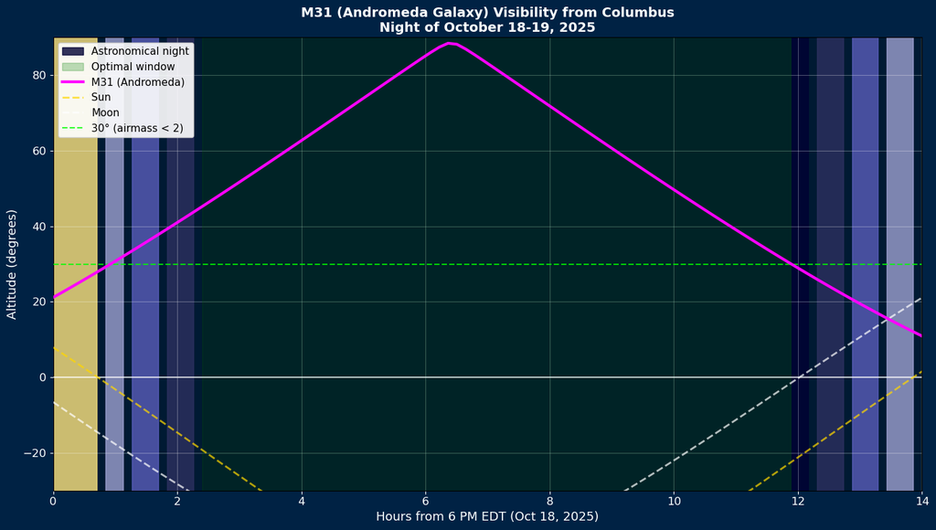

```python
plt.figure(figsize=(14, 8))

plt.fill_between(hours, -90, 90, sun_altaz.alt.deg > 0,
                 color='#FFE680', alpha=0.8, zorder=1)
plt.fill_between(hours, -90, 90, (sun_altaz.alt.deg <= 0) & (sun_altaz.alt.deg > -6),
                 color='#B3B3E6', alpha=0.7, zorder=1)
plt.fill_between(hours, -90, 90, (sun_altaz.alt.deg <= -6) & (sun_altaz.alt.deg > -12),
                 color='#6666CC', alpha=0.7, zorder=1)
plt.fill_between(hours, -90, 90, (sun_altaz.alt.deg <= -12) & (sun_altaz.alt.deg > -18),
                 color='#333366', alpha=0.7, zorder=1)
plt.fill_between(hours, -90, 90, sun_altaz.alt.deg <= -18,
                 color='#000033', alpha=0.8, label='Astronomical night', zorder=1)

plt.fill_between(hours, -90, 90, optimal,
                 color='green', alpha=0.25, label='Optimal window', zorder=2)

plt.plot(hours, m31_altaz.alt.deg, '#FF00FF', linewidth=3,
         label='M31 (Andromeda)', zorder=10)
plt.plot(hours, sun_altaz.alt.deg, '#FFD700', linewidth=2,
         linestyle='--', label='Sun', alpha=0.7, zorder=5)
plt.plot(hours, moon_altaz.alt.deg, '#FFFFFF', linewidth=2,
         linestyle='--', label='Moon', alpha=0.7, zorder=5)

plt.axhline(0, color='white', linestyle='-', alpha=0.7, linewidth=1.5, zorder=3)
plt.axhline(30, color='#00FF00', linestyle='--', alpha=0.8, linewidth=1.5,
            label='30° (airmass < 2)', zorder=3)

plt.xlabel('Hours from 6 PM EDT (Oct 18, 2025)', fontsize=13, color='white')
plt.ylabel('Altitude (degrees)', fontsize=13, color='white')
plt.title('M31 (Andromeda Galaxy) Visibility from Columbus\nNight of October 18-19, 2025',
          fontsize=14, fontweight='bold', color='white')
plt.xlim(0, 14)
plt.ylim(-30, 90)
plt.legend(loc='upper left', fontsize=11, fancybox=True, framealpha=0.9)
plt.grid(alpha=0.3, color='white')

ax = plt.gca()
ax.set_facecolor('#001a33')
plt.gcf().patch.set_facecolor('#002244')
ax.tick_params(colors='white', which='both')

plt.tight_layout()
plt.show()
```

This plot makes the optimal strategy clear. The green shaded region shows when all conditions are met (good altitude, dark sky, and Moon down). M31 (magenta) is high in the sky most of the night, passing nearly overhead. The Sun (gold) stays well below -18° throughout the optimal window. The Moon (white) is conveniently below the horizon.

M31 is perfectly positioned for Columbus in mid-October! You could include this exact plot in a telescope proposal to demonstrate you've carefully planned optimal observing conditions. This is how professional astronomy works - you need to prove your targets are observable before receiving telescope time.

### Multi-Target Scheduling

Often you have several targets to observe in one night and need to optimize the schedule. Let's compare visibility for three different objects to see how to plan an efficient observing run:

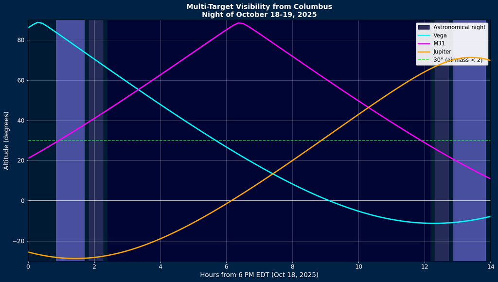

```python
# Define multiple targets for comparison
targets = {
    'Vega': SkyCoord(ra='18h36m56s', dec='+38d47m01s'),
    'M31': SkyCoord(ra='00h42m44s', dec='+41d16m08s'),
    'Jupiter': get_body('jupiter', night_start, columbus)
}

# Assign colors for plotting
colors = {'Vega': '#00FFFF', 'M31': '#FF00FF', 'Jupiter': '#FFA500'}

plt.figure(figsize=(14, 8))

# Plot twilight background zones
plt.fill_between(hours, -90, 90, sun_altaz.alt.deg <= -18,
                 color='#000033', alpha=0.8, label='Astronomical night', zorder=1)
plt.fill_between(hours, -90, 90,
                 (sun_altaz.alt.deg > -18) & (sun_altaz.alt.deg <= -12),
                 color='#333366', alpha=0.7, zorder=1)
plt.fill_between(hours, -90, 90,
                 (sun_altaz.alt.deg > -12) & (sun_altaz.alt.deg <= 0),
                 color='#6666CC', alpha=0.7, zorder=1)

# Plot all targets
for name, coord in targets.items():
    # Jupiter requires recomputing for all times since it moves noticeably
    if name == 'Jupiter':
        coords_night = get_body('jupiter', night_times, columbus)
    else:
        # Fixed stars/galaxies - single coordinate is sufficient
        coords_night = coord
    target_altaz = coords_night.transform_to(altaz_frames)
    plt.plot(hours, target_altaz.alt.deg, color=colors[name],
             linewidth=2.5, label=name, zorder=10)

plt.axhline(0, color='white', linestyle='-', alpha=0.7, linewidth=1.5, zorder=3)
plt.axhline(30, color='#00FF00', linestyle='--', alpha=0.8, linewidth=1.5,
            label='30° (airmass < 2)', zorder=3)

plt.xlabel('Hours from 6 PM EDT (Oct 18, 2025)', fontsize=13, color='white')
plt.ylabel('Altitude (degrees)', fontsize=13, color='white')
plt.title('Multi-Target Visibility from Columbus\nNight of October 18-19, 2025',
          fontsize=14, fontweight='bold', color='white')
plt.xlim(0, 14)
plt.ylim(-30, 90)
plt.legend(loc='upper right', fontsize=11, fancybox=True, framealpha=0.9)
plt.grid(alpha=0.3, color='white')

ax = plt.gca()
ax.set_facecolor('#001a33')
plt.gcf().patch.set_facecolor('#002244')
ax.tick_params(colors='white', which='both')

plt.tight_layout()
plt.show()
```

Now that we've mastered observation planning, let's move on to actually working with the data you'd collect from such observations - FITS image files.

## Working with FITS Files: Real JWST Images

### What is FITS and Why Does Astronomy Use It?

So far we've learned how to query astronomical databases for *catalogs* - tables of measurements like positions, magnitudes, and velocities. But what about actual *images* from telescopes? When you point JWST or Hubble at the sky and take a picture, what format does that data come in?

The answer is **FITS: the Flexible Image Transport System**. Developed in the late 1970s and standardized in 1981, FITS has been astronomy's universal data format for over four decades. Every major observatory outputs FITS files, including Hubble Space Telescope, James Webb Space Telescope, Chandra X-ray Observatory, and ground-based facilities worldwide.

Why not just use JPEG or PNG like everyone else? Several critical reasons. FITS preserves full data precision by storing pixel values as the actual measurements from the detector (electron counts, flux in physical units), not compressed 8-bit RGB values. A JWST pixel might be stored as a 32-bit floating-point number preserving the full measurement precision. FITS files are self-describing, with every file containing extensive metadata in its header - telescope name, instrument configuration, filter, exposure time, observation date, target coordinates, calibration information, and more. You can fully understand the data without any external documentation. FITS handles not just 2D images but also 1D spectra, 3D data cubes, binary tables, multi-extension files, and more. It's a complete scientific data format. Pixel values have physical meaning (electrons per second, Janskys, magnitudes) and units are specified in the header. You know *exactly* what each number represents. FITS includes a standardized system called World Coordinate System (WCS) for mapping pixel coordinates to celestial coordinates, so you know exactly where each pixel points on the sky.

The downside? FITS files are **large** - often hundreds of megabytes to gigabytes, since they store full-precision scientific data. But for research-grade astronomy, there's no substitute.

Let's download and explore real JWST images from the CEERS survey!

### CEERS: Cosmic Evolution Early Release Science Survey

CEERS is one of JWST's flagship Early Release Science programs. It used NIRCam (Near-Infrared Camera) to image the Extended Groth Strip, a well-studied deep field, in multiple infrared filters. The goal is to detect galaxies from when the universe was less than 500 million years old and study galaxy evolution across cosmic time.

These observations are spectacular. JWST's sensitivity allows it to see galaxies 100 times fainter than Hubble in the infrared. The images contain thousands of galaxies at various redshifts, from nearby to the most distant objects ever observed.

We'll download a CEERS mosaic in the F200W filter (2.0 micron near-infrared) from the MAST archive. This is real science-grade data from one of the world's most powerful telescopes!

```python
import urllib.request
import os
import gzip
import shutil

fits_url = "https://archive.stsci.edu/hlsps/ceers/nircam/hlsp_ceers_jwst_nircam_nircam3_f200w_v0.5_i2d.fits.gz"
fits_gz = "ceers_nircam3_f200w.fits.gz"
fits_file = "ceers_nircam3_f200w.fits"

print(f"JWST CEERS NIRCam F200W Image")
print(f"="*60)
print(f"Source: MAST Archive (archive.stsci.edu)")
print(f"Survey: Cosmic Evolution Early Release Science (CEERS)")
print(f"Instrument: JWST/NIRCam")
print(f"Filter: F200W (2.0 microns)")
print(f"Field: Extended Groth Strip")
print(f"Compressed size: ~1.5 GB, Uncompressed: ~2.5 GB")
print(f"="*60)

if not os.path.exists(fits_file):
    if not os.path.exists(fits_gz):
        print(f"\nDownloading {fits_gz}...")
        print(f"This will take several minutes depending on connection speed.\n")
        try:
            urllib.request.urlretrieve(fits_url, fits_gz)
            print(f"\n✓ Downloaded {fits_gz}")
        except Exception as e:
            print(f"\n✗ Download failed: {e}")
            print(f"\nAlternative: Visit https://archive.stsci.edu/hlsp/ceers")
            print(f"Download NIRCam pointing 3, F200W filter manually")
            fits_gz = None
    if os.path.exists(fits_gz):
        print(f"\nDecompressing {fits_gz} (this may take a minute)...")
        with gzip.open(fits_gz, 'rb') as f_in:
            with open(fits_file, 'wb') as f_out:
                shutil.copyfileobj(f_in, f_out)
        print(f"✓ Decompressed to {fits_file}")
        os.remove(fits_gz)
        print(f"✓ Removed {fits_gz} (saved 1.5 GB disk space)")
else:
    print(f"\n✓ {fits_file} already exists")

if os.path.exists(fits_file):
    file_size_gb = os.path.getsize(fits_file) / (1024**3)
    print(f"\n✓ Ready to work with JWST data ({file_size_gb:.2f} GB)")
```

```
JWST CEERS NIRCam F200W Image
============================================================
Source: MAST Archive (archive.stsci.edu)
Survey: Cosmic Evolution Early Release Science (CEERS)
Instrument: JWST/NIRCam
Filter: F200W (2.0 microns)
Field: Extended Groth Strip
Compressed size: ~1.5 GB, Uncompressed: ~2.5 GB
============================================================

Downloading ceers_nircam3_f200w.fits.gz...
This will take several minutes depending on connection speed.
```

```
✓ Downloaded ceers_nircam3_f200w.fits.gz

Decompressing ceers_nircam3_f200w.fits.gz (this may take a minute)...
```

```
✓ Decompressed to ceers_nircam3_f200w.fits
✓ Removed ceers_nircam3_f200w.fits.gz (saved 1.5 GB disk space)

✓ Ready to work with JWST data (2.25 GB)
```

If the download succeeds, you now have a real JWST science image on your computer! This is the same data professional astronomers use for research. The F200W filter observes at 2 microns in the near-infrared, perfect for detecting high-redshift galaxies whose visible light has been redshifted into the infrared by cosmic expansion.

If download fails due to network issues, you can visit the archive directly at https://archive.stsci.edu/hlsp/ceers and download NIRCam pointing 3, F200W filter manually. Now let's open and inspect this FITS file.

### Opening and Inspecting FITS Files

Astropy's `fits` module provides everything needed to work with FITS files. Let's open our JWST image and see what's inside:

```python
from astropy.io import fits

if os.path.exists(fits_file):
    hdulist = fits.open(fits_file)
    print(f"FITS file structure:")
    print(f"="*60)
    hdulist.info()
    print(f"="*60)
    print(f"\nThe file contains {len(hdulist)} HDUs (Header-Data Units)")
else:
    print(f"File {fits_file} not found.")
```

```
FITS file structure:
============================================================
Filename: ceers_nircam3_f200w.fits
No.    Name      Ver    Type      Cards   Dimensions   Format
  0  PRIMARY       1 PrimaryHDU     374   ()
  1  SCI_BKSUB     1 ImageHDU        76   (10500, 4800)   float64
  2  SCI           1 ImageHDU        75   (10500, 4800)   float32
  3  ERR           1 ImageHDU        10   (10500, 4800)   float32
  4  CON           1 ImageHDU         9   (10500, 4800)   int32
  5  WHT           1 ImageHDU         9   (10500, 4800)   float32
  6  VAR_POISSON    1 ImageHDU         9   (10500, 4800)   float32
  7  VAR_RNOISE    1 ImageHDU         9   (10500, 4800)   float32
  8  VAR_FLAT      1 ImageHDU         9   (10500, 4800)   float32
  9  BKGD          1 ImageHDU        39   (10500, 4800)   float64
 10  BKGMASK       1 ImageHDU        39   (10500, 4800)   float32
 11  HDRTAB        1 BinTableHDU    816   24R x 403C   [23A, 5A, 3A, 48A, 7A, 13A, 5A, 5A, 7A, 10A, 4A, L, D, D, D, D, 4A, 18A, 57A, 22A, 3A, D, 20A, D, 10A, 12A, 23A, 23A, 26A, 11A, 5A, 3A, 3A, 2A, 1A, 2A, 1A, L, 12A, 24A, 2A, 26A, 20A, 27A, 10A, K, L, L, L, L, 5A, 1A, 5A, D, D, D, D, D, D, D, D, D…
 12  ASDF          1 BinTableHDU     11   1R x 1C   [36478B]
```

```
============================================================

The file contains 13 HDUs (Header-Data Units)
```

### Reading the FITS Header

The header contains all the metadata about how this image was taken. Let's extract the key information:

```python
if os.path.exists(fits_file):
    # Extract primary HDU (Header Data Unit)
    primary = hdulist[0]
    header = primary.header

    # Read key metadata from header using .get() for safe access
    print(f"Key Observation Information:")
    print(f"="*60)
    print(f"Telescope:        {header.get('TELESCOP', 'N/A')}")
    print(f"Instrument:       {header.get('INSTRUME', 'N/A')}")
    print(f"Filter:           {header.get('FILTER', 'N/A')}")
    print(f"Observation date: {header.get('DATE-OBS', 'N/A')}")
    print(f"Total exposure:   {header.get('TEXPTIME', 0):.1f} seconds")
    print(f"Data units:       {header.get('BUNIT', 'N/A')}")
    print(f"Target field:     {header.get('TARGPROP', 'EGS Field')}")
    print(f"Image size:       {header.get('NAXIS1', 0)} × {header.get('NAXIS2', 0)} pixels")
    print(f"="*60)
```

```
Key Observation Information:
============================================================
Telescope:        JWST
Instrument:       NIRCAM
Filter:           F200W
Observation date: 2022-06-22
Total exposure:   2834.5 seconds
Data units:       N/A
Target field:     MIRI3
Image size:       0 × 0 pixels
============================================================
```

### Accessing the Image Data

Now let's get the actual pixel data and examine its properties:

```python
if os.path.exists(fits_file):
    # Access image data array from primary HDU
    image_data = primary.data

    # Some FITS files store data in extension HDUs instead of primary
    if image_data is None:
        for i, hdu in enumerate(hdulist):
            if hdu.data is not None:
                print(f"Found image data in HDU {i}")
                image_data = hdu.data
                header = hdu.header
                break

    if image_data is not None:
        print(f"Image Data Properties:")
        print(f"="*60)
        print(f"Shape:     {image_data.shape} pixels")
        print(f"Data type: {image_data.dtype}")
        print(f"Size:      {image_data.nbytes / (1024**3):.2f} GB in memory")

        # Use np.nanmin/nanmax/etc to ignore NaN values in statistics
        print(f"\nStatistics (in MJy/sr):")
        print(f"  Minimum:     {np.nanmin(image_data):.6f}")
        print(f"  Maximum:     {np.nanmax(image_data):.6f}")
        print(f"  Median:      {np.nanmedian(image_data):.6f}")
        print(f"  Mean:        {np.nanmean(image_data):.6f}")
        print(f"  Std dev:     {np.nanstd(image_data):.6f}")
        n_nans = np.isnan(image_data).sum()
        print(f"\nNaN pixels:  {n_nans:,} ({100*n_nans/image_data.size:.2f}%)")
        print(f"="*60)
    else:
        print("Could not find image data in any HDU")
```

```
Found image data in HDU 1
Image Data Properties:
============================================================
Shape:     (4800, 10500) pixels
Data type: >f8
Size:      0.38 GB in memory

Statistics (in MJy/sr):
```

```
  Minimum:     -1.950443
  Maximum:     350.751251
```

```
  Median:      0.000000
  Mean:        0.006953
```

```
  Std dev:     0.313088

NaN pixels:  0 (0.00%)
============================================================
```

### The Challenge of Displaying Astronomical Images

Let's try displaying this image with a naive approach using matplotlib's standard `imshow()` function:

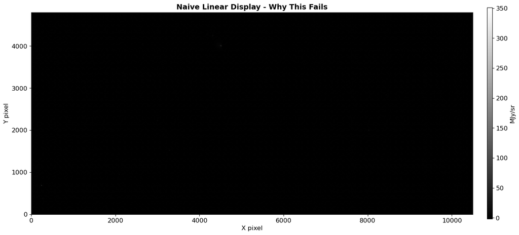

```python
if os.path.exists(fits_file) and image_data is not None:
    aspect_ratio = image_data.shape[0] / image_data.shape[1]
    fig_width = 14
    fig_height = fig_width * aspect_ratio

    plt.figure(figsize=(fig_width, fig_height))
    plt.imshow(image_data, cmap='gray', origin='lower')
    plt.colorbar(label='MJy/sr', fraction=0.03, pad=0.03, aspect=40)
    plt.title('Naive Linear Display - Why This Fails', fontsize=14, fontweight='bold')
    plt.xlabel('X pixel')
    plt.ylabel('Y pixel')
    plt.tight_layout()
    plt.show()
elif os.path.exists(fits_file):
    print("Skipping display - no image data loaded")
```

### Proper FITS Visualization with Astropy

Astropy's `visualization` module provides sophisticated tools specifically designed for astronomical images. Let's explore several different stretching options to see their effects. We'll start with the most popular combination: ZScaleInterval with AsinhStretch.

**ZScaleInterval** is an algorithm originally from IRAF (Image Reduction and Analysis Facility, a classic astronomical software package from the 1980s-90s) and popularized by DS9 (a widely-used FITS viewer). It automatically finds optimal minimum and maximum intensity values by analyzing the image histogram. It intelligently clips extreme outliers while preserving the full dynamic range of actual astronomical sources.

**AsinhStretch** applies an inverse hyperbolic sine function. It acts linear for faint features (preserving low signal-to-noise detail), acts logarithmic for bright features (compressing the high end), and handles negative values gracefully (important for background-subtracted images).

Let's apply these to reveal the full beauty of our JWST image:

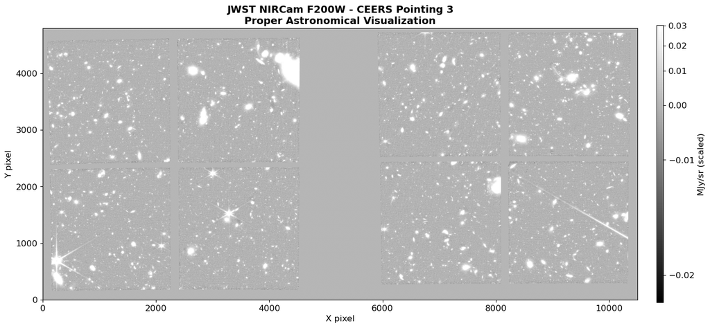

```python
if os.path.exists(fits_file) and image_data is not None:
    from astropy.visualization import ZScaleInterval, AsinhStretch, ImageNormalize

    # Combine interval (ZScale finds optimal min/max) with stretch (AsinhStretch compresses dynamic range)
    norm = ImageNormalize(image_data,
                          interval=ZScaleInterval(),
                          stretch=AsinhStretch())

    # Calculate figure size maintaining aspect ratio
    aspect_ratio = image_data.shape[0] / image_data.shape[1]
    fig_width = 14
    fig_height = fig_width * aspect_ratio

    plt.figure(figsize=(fig_width, fig_height))

    # origin='lower' puts (0,0) at bottom-left (astronomical convention)
    plt.imshow(image_data, cmap='gray', origin='lower', norm=norm)
    plt.colorbar(label='MJy/sr (scaled)', fraction=0.03, pad=0.03, aspect=40)
    plt.title('JWST NIRCam F200W - CEERS Pointing 3\nProper Astronomical Visualization',
              fontsize=14, fontweight='bold')
    plt.xlabel('X pixel', fontsize=12)
    plt.ylabel('Y pixel', fontsize=12)
    plt.tight_layout()
    plt.show()
elif os.path.exists(fits_file):
    print("Skipping visualization - no image data loaded")
```

**What a difference!** Now you can see hundreds or thousands of individual galaxies at various distances, faint diffuse objects barely above the noise, bright compact sources (nearby galaxies or foreground stars), and extended structures showing galaxy morphology. This is the full scientific content of the image, from the faintest detectable galaxies to the brightest sources, all visible simultaneously thanks to the non-linear stretch. This is exactly how astronomers use DS9, SAOImage, and other professional FITS viewers.

The combination of `ZScaleInterval` and `AsinhStretch` is already effective for JWST images. But there are other options available. Let's explore a few alternatives to see their effects:

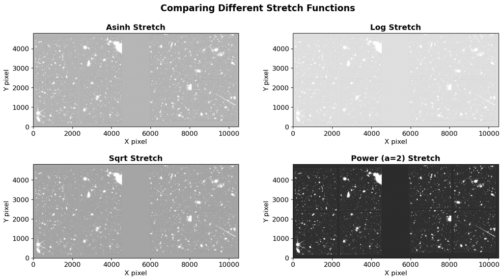

```python
if os.path.exists(fits_file) and image_data is not None:
    from astropy.visualization import LogStretch, SqrtStretch, PowerStretch

    stretches = {
        'Asinh': AsinhStretch(),
        'Log': LogStretch(),
        'Sqrt': SqrtStretch(),
        'Power (a=2)': PowerStretch(a=2)
    }

    aspect_ratio = image_data.shape[0] / image_data.shape[1]
    fig_width = 16
    fig_height = fig_width * aspect_ratio

    fig, axes = plt.subplots(2, 2, figsize=(fig_width, fig_height))
    axes = axes.flatten()

    for i, (name, stretch) in enumerate(stretches.items()):
        norm = ImageNormalize(image_data, interval=ZScaleInterval(), stretch=stretch)
        axes[i].imshow(image_data, cmap='gray', origin='lower', norm=norm)
        axes[i].set_title(f'{name} Stretch', fontsize=14, fontweight='bold')
        axes[i].set_xlabel('X pixel')
        axes[i].set_ylabel('Y pixel')

    plt.suptitle('Comparing Different Stretch Functions', fontsize=16, fontweight='bold')
    plt.subplots_adjust(wspace=0.1, hspace=0.4)
    plt.show()
elif os.path.exists(fits_file):
    print("Skipping stretch comparison - no image data loaded")
```

Each stretch function reveals the data differently. LogStretch provides very strong compression at the bright end, useful for images with extremely bright sources. SqrtStretch is gentler and common for optical images. PowerStretch is adjustable via the `a` parameter, allowing you to tune the stretch to your specific data.

The PowerStretch applies a transformation of the form:

$$y = x^{a}$$

where $x$ is the normalized input pixel value (ranging from 0 to 1) and $y$ is the output display value. The parameter $a$ controls the degree of non-linearity:

- When $a = 1$: Linear stretch (no transformation)
- When $a < 1$: Compresses bright values more than faint ones (e.g., $a = 0.5$ gives a square root-like stretch)
- When $a > 1$: Expands bright values relative to faint ones

For $a = 2$ (which we use here), the transformation becomes $y = x^2$, which expands the bright end and compresses the faint end - quite different from SqrtStretch!

### Zooming In on Individual Galaxies

JWST images contain so much detail that it's worth zooming into regions to see individual galaxy morphologies. Let's extract and display a smaller region with interesting structure. Based on the stretch comparison above, we'll use PowerStretch(a=2) for optimal detail:

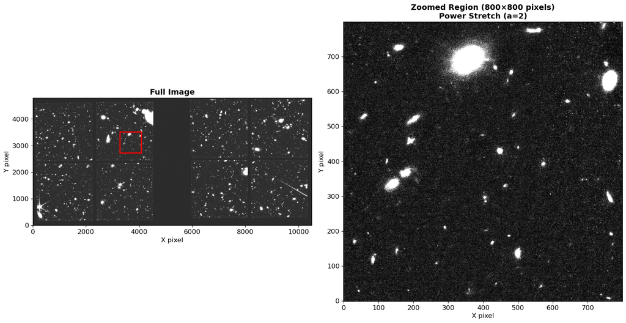

```python
if os.path.exists(fits_file) and image_data is not None:
    from astropy.visualization import PowerStretch

    # Calculate zoom region center (65% down, 35% across)
    cy, cx = int(image_data.shape[0] * 0.65), int(image_data.shape[1] * 0.35)
    size = 400

    # Extract subregion using array slicing
    zoom = image_data[cy-size:cy+size, cx-size:cx+size]

    # Re-normalize for zoomed region to optimize contrast
    zoom_norm = ImageNormalize(zoom,
                                interval=ZScaleInterval(),
                                stretch=PowerStretch(a=2))

    fig, axes = plt.subplots(1, 2, figsize=(16, 8))

    # Left panel: full image with zoom box
    axes[0].imshow(image_data, cmap='gray', origin='lower', norm=norm)
    from matplotlib.patches import Rectangle

    # Draw rectangle showing zoom region
    rect = Rectangle((cx-size, cy-size), 2*size, 2*size,
                     linewidth=2, edgecolor='red', facecolor='none')
    axes[0].add_patch(rect)
    axes[0].set_title('Full Image', fontsize=14, fontweight='bold')
    axes[0].set_xlabel('X pixel')
    axes[0].set_ylabel('Y pixel')

    # Right panel: zoomed region
    axes[1].imshow(zoom, cmap='gray', origin='lower', norm=zoom_norm)
    axes[1].set_title('Zoomed Region (800×800 pixels)\nPower Stretch (a=2)',
                      fontsize=14, fontweight='bold')
    axes[1].set_xlabel('X pixel')
    axes[1].set_ylabel('Y pixel')

    plt.tight_layout()
    plt.show()
elif os.path.exists(fits_file):
    print("Skipping zoom - no image data loaded")
```

By extracting a subregion and re-normalizing with the PowerStretch, we optimize the contrast specifically for these objects. Each bright spot is likely a galaxy. Compact, bright sources are nearby galaxies or possibly foreground stars. Extended structures show morphological features of galaxies at moderate distances. Faint, diffuse patches are extremely distant galaxies whose light has traveled billions of years. JWST's infrared sensitivity is revolutionary - it can detect galaxies so distant that their light was emitted when the universe was less than 5% of its current age. Some galaxies in this image may be over 13 billion light-years away!

### Creating RGB Color Images

JWST observes through multiple filters at different wavelengths. By combining three filters, we can create color images that reveal galaxy properties. The typical combination for CEERS uses F115W (1.15 μm) for the blue channel, F200W (2.00 μm) for the green channel (we have this!), and F444W (4.44 μm) for the red channel.

This isn't "true color" since these are all infrared wavelengths invisible to our eyes, but it creates beautiful images and reveals important science. Blue objects indicate hot stars and active star formation. Red objects indicate cool stars, dust, or high-redshift galaxies. Color gradients show stellar population differences across galaxies.

The process requires downloading all three filter images for the same pointing from MAST at https://archive.stsci.edu/hlsp/ceers, ensuring images are pixel-aligned (CEERS mosaics already are), applying ZScale and AsinhStretch (or PowerStretch) to each independently, normalizing each channel to the range [0, 1], stacking as RGB using `rgb = np.dstack([red, green, blue])`, and displaying with `plt.imshow(rgb, origin='lower')`. The result is stunning color images like NASA press releases, where colors reveal physical properties rather than visual appearance. Blue indicates hot or young stars, while red indicates cool, dusty, or distant objects.

Creating these false-color composites is how NASA produces those gorgeous press-release images. The "color" doesn't represent what your eye would see, but it encodes important astrophysical information about stellar populations, dust content, and redshift. If you want to try this yourself, download the F115W and F444W images for NIRCam pointing 3 from MAST and combine them with our F200W image!

In the final section, we properly close the FITS file to free up system resources. This is good practice when working with file handles in Python - always close files when you're done with them to prevent memory leaks and ensure data integrity.

```python
# Close FITS file to free system resources
if os.path.exists(fits_file):
    hdulist.close()
```

## Summary

### What You Can Now Do

After working through this material, you should be able to:

- Plan observations accounting for target altitude, airmass, twilight, and lunar phase
- Create professional visibility plots for telescope proposals
- Transform coordinates between celestial (ICRS) and local (AltAz) systems
- Download and analyze FITS images from JWST, Hubble, and ground-based observatories
- Apply appropriate scaling and stretching to reveal astronomical image content
- Determine optimal observing windows for any target from any location on Earth

### Practice Suggestions

To solidify these concepts:

1. Plan observations of M31 from Columbus for October 25, 2025 and create a visibility plot
2. Find when Betelgeuse transits (reaches highest altitude) tonight and compute its airmass
3. Download a different CEERS filter (F115W or F444W) and compare stretches
4. Compare Vega's visibility from Columbus versus Mauna Kea on the same night
5. Write a function that determines if a target is observable (alt > 30°, Sun < -18°, Moon down)
6. Find optimal dates this year for observing Jupiter at airmass < 1.5 from Columbus
7. Create a three-target visibility plot for an upcoming new moon period

### Looking Ahead

You now have a complete toolkit combining Lectures 13 and 14. You can query astronomical databases, work with coordinates and units, transform between coordinate systems, plan observations with all relevant constraints, and analyze FITS images from world-class telescopes. In Week 9, you'll see how your classmates apply these techniques to real research projects. The workflow you've learned - querying catalogs, planning observations, and analyzing images - is exactly what professional astronomers use for Hubble proposals, JWST early release science, and discovering new phenomena. **You're now equipped to do real astronomy!** 🔭✨